# Task 1

Since the performance of decision algorithm for the red group is not fixed, we simulated 1000 trials of the experiment and report the results as histograms of respective scores.

[figure not shown]

# Task 2

### Setup

- Dataset: COMPAS
- Task: Binary classification
- Sensitive attribute: sex
- Random data split into train:test (70:30) ratio
- GradientBoosting and DecisionTree algorithms from sklearn library
- Debiased variant of GradientBoosting trained by reweighting samples based on cardinality of sensitive attribute
- 100 runs across randomly sampled seeds

### Data visualization 1

We draw a scatterplot of given fairness metric vs model accuracy for all 100 experiments

[figure not shown]

We notice a positive correlation of accuracy with `demographic_parity` and `equal_opportunity` errors, but a negative correlation with `predictive_parity_value` error.

### Data visualization 2

Note that in the above plot, the points for GradientBoosting and BalancedGradientBoosting greatly overlap since the variance introduced by random data split is rather large. We want to assess an impact of model choice, accounting for variance introduced by random data splits. For every seed, we compute differences between metrics across the models and only then aggregate the relative metrics across all seeds.

[figure not shown]

We see that trends still hold with better separation across compared models.

### Data visualization 3

Finally, we want to inspect each cluster in the above plot to see if the trends hold for the same pair of models, across sampled data splits.

[figure not shown]

We see that `demographic_parity` error is still in positive correlation with accuracy, and `predictive_parity_value` error - in negative correlation, even when 2 tested models are fixed and only the data splits impact the model performance. Note however that the trend for `equal_opportunity` doesn't translate to this scenario.

This is rather interesting, the result suggests that the correlation of model accuracy with an `equal_opportunity` error is qualitative, based on the choosen model type, instead of being quantitative sideeffect of increased model accuracy.

# Appendix

## Utils

```python
import numpy as np
```

```python
def demographic_parity(ypred: np.ndarray, s: np.ndarray):
    ypred_s0 = ypred[s <= 0.5]
    ypred_s1 = ypred[s > 0.5]
    if len(ypred_s0) == 0 or len(ypred_s1) == 0:
        return 0.
    p_ypred_s0 = (ypred_s0 > 0.5).mean()
    p_ypred_s1 = (ypred_s1 > 0.5).mean()
    return np.abs(p_ypred_s0 - p_ypred_s1) * 100

def equal_opportunity(ypred: np.ndarray, y: np.ndarray, s: np.ndarray):
    ypred_y1_s0 = ypred[(y > 0.5) & (s <= 0.5)]
    ypred_y1_s1 = ypred[(y > 0.5) & (s > 0.5)]
    if len(ypred_y1_s0) == 0 or len(ypred_y1_s1) == 0:
        return 0.
    p_ypred_y1_s0 = (ypred_y1_s0 > 0.5).mean()
    p_ypred_y1_s1 = (ypred_y1_s1 > 0.5).mean()
    return np.abs(p_ypred_y1_s0 - p_ypred_y1_s1) * 100

def predictive_parity_value(ypred: np.ndarray, y: np.ndarray, s: np.ndarray):
    y_ypred1_s0 = y[(ypred > 0.5) & (s <= 0.5)]
    y_ypred1_s1 = y[(ypred > 0.5) & (s > 0.5)]
    if len(y_ypred1_s0) == 0 or len(y_ypred1_s1) == 0:
        return 0.
    p_y_ypred1_s0 = (y_ypred1_s0 > 0.5).mean()
    p_y_ypred1_s1 = (y_ypred1_s1 > 0.5).mean()
    return np.abs(p_y_ypred1_s0 - p_y_ypred1_s1) * 100

def get_stats(ypred: np.ndarray, y: np.ndarray, s: np.ndarray):
    ret = {}
    ret["demographic_parity"] = demographic_parity(ypred, s)
    ret["equal_opportunity"] = equal_opportunity(ypred, y, s)
    ret["predictive_parity_value"] = predictive_parity_value(ypred, y, s)
    ret["accuracy"] = ((ypred > 0.5) == (y > 0.5)).mean() * 100
    return ret
```

## Task 1

```python
import matplotlib.pyplot as plt
```

```python
def sample_data():
    N = 100
    blue_y = np.zeros([N])
    blue_y[:len(blue_y)*8//10] = 1.
    blue_ypred = np.zeros_like(blue_y)
    blue_ypred[:len(blue_ypred)*6//10] = 1.
    blue_ypred[len(blue_ypred)*8//10:len(blue_ypred)*8//10+len(blue_ypred)//20] = 1.

    red_y = np.zeros([N//9])
    red_y[:len(red_y)//2] = 1.
    red_ypred = np.zeros_like(red_y)
    red_ypred[np.random.choice(len(red_y), [len(red_y)//2], replace=False)] = 1.

    ypred = np.concatenate([blue_ypred, red_ypred])
    y = np.concatenate([blue_y, red_y])
    s = np.concatenate([np.zeros_like(blue_y), np.ones_like(red_y)])
    return ypred, y, s
```

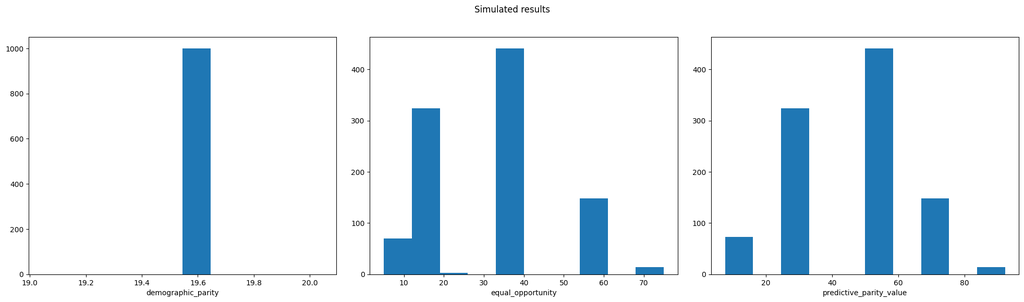

```python
ret = {"demographic_parity": [], "equal_opportunity": [], "predictive_parity_value": []}
for i in range(1000):
    ypred, y, s = sample_data()
    ret["demographic_parity"].append(demographic_parity(ypred, s))
    ret["equal_opportunity"].append(equal_opportunity(ypred, y, s))
    ret["predictive_parity_value"].append(predictive_parity_value(ypred, y, s))

fig, axs = plt.subplots(1,3, figsize=(20,6))
for ax, (k, v) in zip(axs, ret.items()):
    ax.hist(v)
    ax.set_xlabel(k)

fig.suptitle("Simulated results")
plt.tight_layout(pad=2.)
fig.savefig("task1.png")
```

## Task 2

```python
import pandas as pd
import os
from sklearn.model_selection import train_test_split
from sklearn.ensemble import GradientBoostingClassifier
from sklearn.tree import DecisionTreeClassifier
from sklearn.utils import compute_sample_weight
import json
import tqdm
```

```python
def load_compas_data(path="datasets/compas/raw", sensitive_attribute="sex"):
    # We use the same features_to_keep and categorical_features from AIF360 at https://github.com/Trusted-AI/AIF360/blob/master/aif360/datasets/compas_dataset.py

    features_to_keep = ["sex","age","age_cat","race","juv_fel_count","juv_misd_count","juv_other_count","priors_count","c_charge_degree","c_charge_desc","two_year_recid"]
    categorical_features = ["age_cat", "c_charge_degree", "c_charge_desc"]

    df = pd.read_csv(os.path.join(path, "compas-scores-two-years.csv"), index_col = 0)


    # df = df.dropna()
    df = df[df["days_b_screening_arrest"] <= 30]
    df = df[df["days_b_screening_arrest"] >= -30]
    df = df[df["is_recid"] != -1]
    df = df[df["c_charge_degree"] != "O"]
    df = df[df["score_text"] != "N/A"]
    df = df[features_to_keep]

    if sensitive_attribute == "sex":
        s = df[sensitive_attribute]
        s = (s == "Male").astype(int).to_frame()
        categorical_features.append("race")
    elif sensitive_attribute == "race":
        s = df[sensitive_attribute]
        s = (s == "Caucasian").astype(int).to_frame()
        categorical_features.append("sex")
    else:
        print("error")


    y = (df["two_year_recid"] ==  1 ).astype(int).to_frame()


    X = df.drop(columns=["two_year_recid", sensitive_attribute])
    X = pd.get_dummies(X, columns=categorical_features)

    # Convert all non-uint8 columns to float32
    uint8_cols = X.select_dtypes(exclude="uint8").columns
    X[uint8_cols] = X[uint8_cols].astype("float32")

    return X, y, s
```

```python
def experiment(seed):
    X, y, s = load_compas_data()
    X = X.to_numpy().squeeze()
    y  = y.to_numpy().squeeze()
    s = s.to_numpy().squeeze()

    X_train, X_test, y_train, y_test, s_train, s_test = train_test_split(X, y, s, test_size=0.3, stratify=y, random_state=seed)
    model1 = GradientBoostingClassifier().fit(X_train, y_train)
    model2 = DecisionTreeClassifier().fit(X_train, y_train)
    model3 = GradientBoostingClassifier().fit(X_train, y_train, sample_weight=compute_sample_weight("balanced", s_train))
    model1_stats = get_stats(model1.predict(X_test), y_test, s_test)
    model2_stats = get_stats(model2.predict(X_test), y_test, s_test)
    model3_stats = get_stats(model3.predict(X_test), y_test, s_test)
    model1_stats["model"] = "GradientBoosting"
    model2_stats["model"] = "DecisionTree"
    model3_stats["model"] = "BalancedGradientBoosting"
    return {"GradientBoosting": model1_stats, "DecisionTree": model2_stats, "BalancedGradientBoosting": model3_stats}
```

```python
data = []
seeds = np.random.choice(2**16, size=(100,), replace=False)
for seed in tqdm.tqdm(seeds):
    data.append(experiment(seed))
with open("data.json", "w") as f:
    json.dump(data, f)
```

```python
with open("data.json") as f:
    data = json.load(f)
relative_data = []
for x in data:
    ks = list(x.keys())
    for i in range(len(ks)):
        for j in range(i+1, len(ks)):
            res = {}
            k1 = ks[i]
            k2 = ks[j]
            for metric in ["demographic_parity", "equal_opportunity", "predictive_parity_value", "accuracy"]:
                res["model1"] = k1
                res["model2"] = k2
                res["model1_model2"] = f"{k1}_vs_{k2}"
                res[f"relative_{metric}"] = x[k1][metric] - x[k2][metric]
            relative_data.append(res)
```

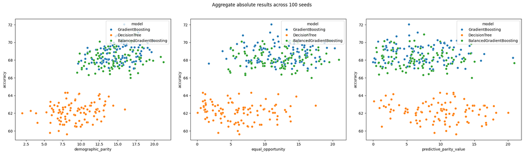

```python
import seaborn as sns
metrics = ["demographic_parity", "equal_opportunity", "predictive_parity_value"]
fig, axs = plt.subplots(1, 3, figsize=(20,6))
df = pd.DataFrame.from_records([v for x in data for v in x.values()])
for ax, metric in zip(axs, metrics):
    sns.scatterplot(df, x=metric, y="accuracy", hue="model", ax=ax)
    sns.move_legend(ax, loc="upper right")
fig.suptitle("Aggregate absolute results across 100 seeds")
plt.tight_layout(pad=2.)
fig.savefig("task2_aggregate_absolute.png")
```

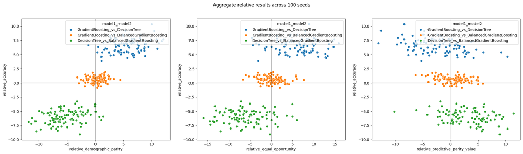

```python
metrics = ["demographic_parity", "equal_opportunity", "predictive_parity_value"]
fig, axs = plt.subplots(1, 3, figsize=(20,6))
df = pd.DataFrame.from_records(relative_data)
for ax, metric in zip(axs, metrics):
    sns.scatterplot(df, x=f"relative_{metric}", y="relative_accuracy", ax=ax, hue="model1_model2")
    sns.move_legend(ax, loc="upper right")
    ax.axvline(0, color="black", alpha=0.3)
    ax.axhline(0, color="black", alpha=0.3)

fig.suptitle("Aggregate relative results across 100 seeds")
plt.tight_layout(pad=2.)
fig.savefig("task2_aggregate_relative.png")
```

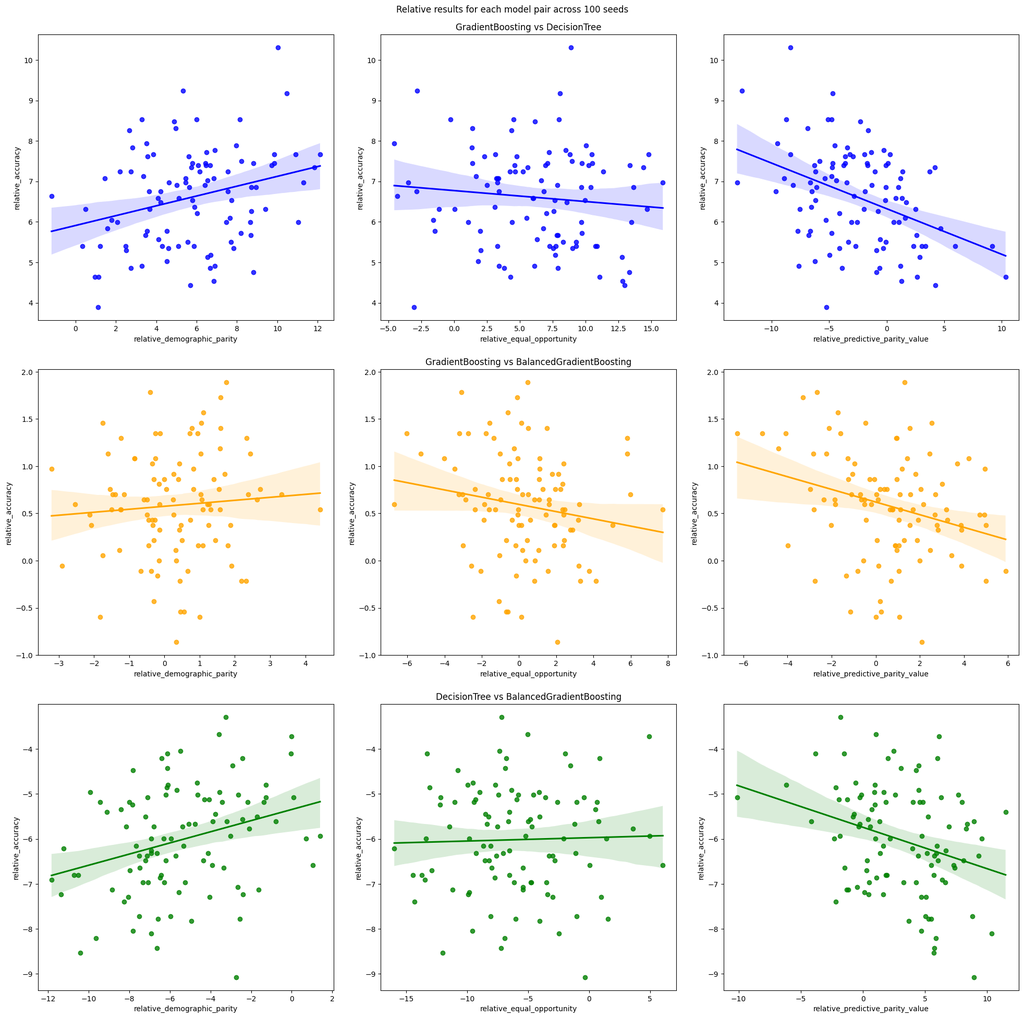

```python
metrics = ["demographic_parity", "equal_opportunity", "predictive_parity_value"]
models = ["GradientBoosting", "DecisionTree", "BalancedGradientBoosting"]
colors = ["blue", "orange", "green"]
fig, axs = plt.subplots(3, 3, figsize=(20,20))
df = pd.DataFrame.from_records(relative_data)

it = -1
for i in range(len(models)):
    for j in range(i+1, len(models)):
        it += 1
        model1 = models[i]
        model2 = models[j]
        sub_df = df[(df["model1"] == model1) & (df["model2"] == model2)]
        for l, (ax, metric) in enumerate(zip(axs[it], metrics)):
            sns.regplot(sub_df, x=f"relative_{metric}", y=f"relative_accuracy", ax=ax, color=colors[it])
            if l == 1:
                ax.set_title(f"{model1} vs {model2}")

fig.suptitle("Relative results for each model pair across 100 seeds")
plt.tight_layout(pad=2.)
fig.savefig("task2_grouped_relative.png")
```